# African American in prison proportion

Kevin Fu

2022-11-01

## Abstract

Inequality in the incarceration system in the U.S. has a long history, and this assignment is about finding the patterns of inequality from the incarceration data provided by Vera. The data set includes incarceration information in each county in the U.S. and will be used to find the inequality trend in the incarceration field.

## Introduction

Incarceration trends data in the U.S. collected by Vera included two parts, the census of jails data that covers all prisons and has been conducted every five to eight years since 1970, and the Annual Survey of Jails data that covers about one-third of jails(including almost all the largest prisons) that has been conducted in non-census years since 1982. Inequality patterns are hidden in the incarceration trends data because racism and injustice behavior have inveteracy in the incarceration field in America. For example, according to research of Vera, African Americans took up 13% of the population in the United States, but they took over 35% of the incarcerated population. And also, more than 80% of all arrests are for low-level, nonviolent offenses and conduct related to poverty. The direct stakeholders impacted by research into this dataset are people from Vera who created the data set and people who use the information for research or journal. The indirect stakeholders affected by the data set are the prisoners and people who have worked in and with the field of Incarceration in the United States. In this vein, the central value should be we should protect the specific prisoner information a little more. And my question is, has the injustice trend in the incarceration field towards certain races increased over the year?

## Data Summary

```r
blackprop_2018 - blackprop_1998
```

```
## [1] -0.07874074
```

```r
whiteprop_2018 - whiteprop_1998
```

```
## [1] 0.0572124
```

```r
latinprop_2018 - latinprop_1998
```

```
## [1] -0.006060896
```

```r
asianprop_2018 - asianprop_1998
```

```
## [1] -0.002015296
```

Because I’m trying to find if the injustice trend to certain races has increased or not in the incarceration field, I took the recent proportion of people in prison for African Americans, white, Latinos, and Asian and compared them with the data about them 20 years ago. And according to the four values, the proportions for Latinos and Asians do not change much, and they decrease a little. The proportion of African Americans has decreased by about 8 percent, and the proportion of white people has increased by about 6 percent.

##Growth of the U.S. Prison Population

```r
get_year_jail_pop()
```

```
## # A tibble: 49 × 2
##     year   total
##    <int>   <dbl>
##  1  1970 160727.
##  2  1971 155679.
##  3  1972 156234.
##  4  1973 156788.
##  5  1974 157342.
##  6  1975 157896.
##  7  1976 158451.
##  8  1977 159005.
##  9  1978 160827.
## 10  1979 172565.
## # … with 39 more rows
```

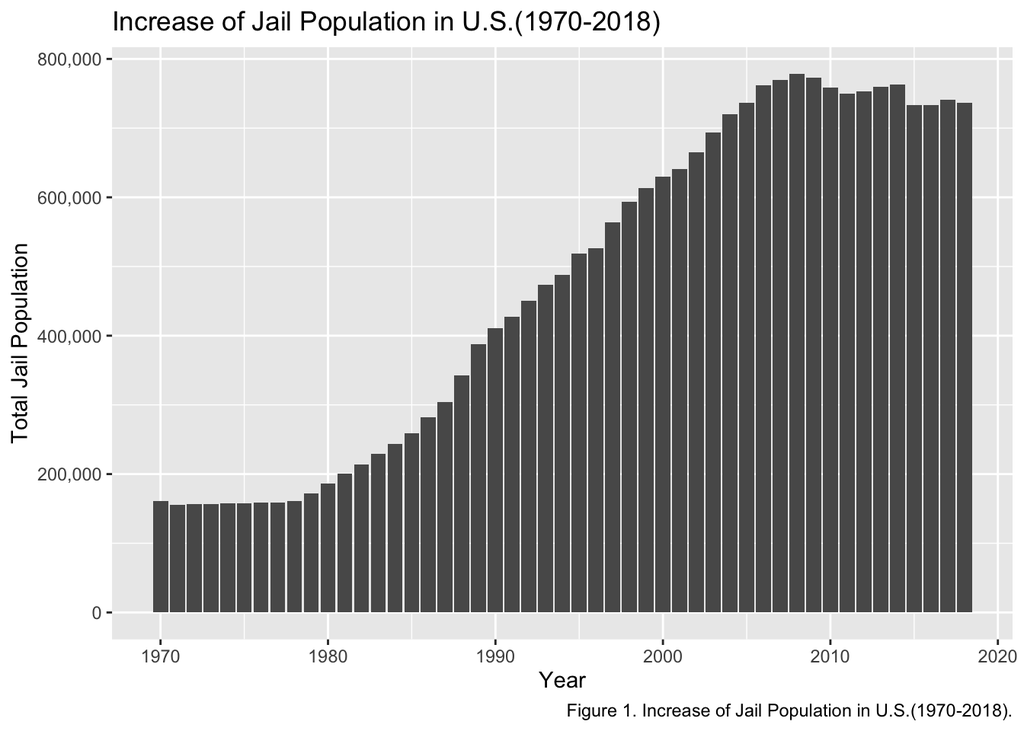

```r
plot_jail_pop_for_us()
```

The graph shows the increase in jail population from 1970 to 2018, and it reveals a pattern of increasing population in jail in the United States for most of the time, especially between 1980 to 2010, but between 2010 to 2018, there is a showing of decreasing pattern showing. And my question for this graph is, what is the reason behind this decreasing pattern?

##Growth of Prison Population by State

```r
get_jail_pop_by_states(c("GA", "WA", "NV"))
```

```
## # A tibble: 147 × 3
## # Groups:   year [49]
##     year state total
##    <int> <chr> <dbl>
##  1  1970 GA    6726
##  2  1970 NV     755
##  3  1970 WA    2277
##  4  1971 GA    6943.
##  5  1971 NV     792.
##  6  1971 WA    1952.
##  7  1972 GA    7221.
##  8  1972 NV     828.
##  9  1972 WA    2059.
## 10  1973 GA    7500.
## # … with 137 more rows
```

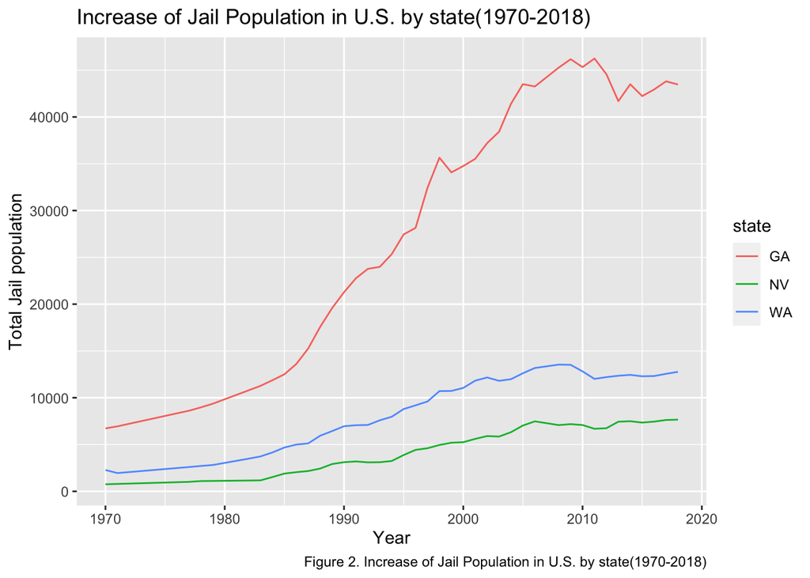

```r
plot_jail_pop_by_states(c("GA", "WA", "NV"))
```

I picked three states for graphing, Georgia, Nevada, and Washington, which are the states I have lived in or currently live in. I chose those states because I want to know the increased jail population of the states I have a history with. And according to the graph, their jail population seems to grow, and Georgia is the state that has the most dramatic change. And my question for this part is, why is a certain state increased more severely than the other state?

##Proportion of Prison Population of African American compared with whole population

```r
get_black_prop_for_us()
```

```
## # A tibble: 49 × 3
##     year prop_black_jail prop_black_pop
##    <int>           <dbl>          <dbl>
##  1  1970               0              0
##  2  1971               0              0
##  3  1972               0              0
##  4  1973               0              0
##  5  1974               0              0
##  6  1975               0              0
##  7  1976               0              0
##  8  1977               0              0
##  9  1978               0              0
## 10  1979               0              0
## # … with 39 more rows
```

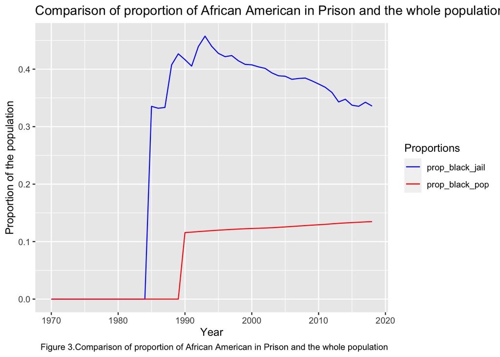

```r
plot_black_prop_for_us()
```

To find the inequality pattern, I compared the proportion of African Americans in the jail population with the proportion of African Americans in the United States population from 1970 to 2018. The graph clearly shows that the ratio of African Americans in jail is higher than the proportion of the whole population. This proved the inequality because African Americans took up about 13% of the people in the United States, but their proportion in jail was nearly three times higher. And my question for this graph is, with the reveal of the inequality, what can make the proportion of African Americans in prison lower?

##Map of African American Proportion in Prison by selected year

```r
get_black_prop_year(1998)
```

```
## # A tibble: 51 × 2
##    state    total
##    <chr>    <dbl>
##  1 AK      0.0256
##  2 AL      0.620
##  3 AR      0.407
##  4 AZ      0.207
##  5 CA      0.227
##  6 CO      0.186
##  7 CT    NaN
##  8 DC      0.941
##  9 DE    NaN
## 10 FL      0.465
## # … with 41 more rows
```

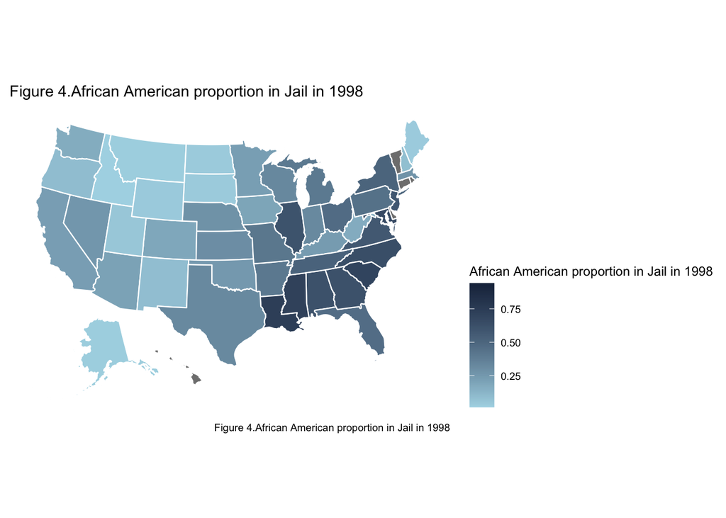

```r
plot_black_prop_year(1998)
```

```r
get_black_prop_year(2018)
```

```
## # A tibble: 51 × 2
##    state    total
##    <chr>    <dbl>
##  1 AK      0.0410
##  2 AL      0.471
##  3 AR      0.359
##  4 AZ      0.148
##  5 CA      0.203
##  6 CO      0.199
##  7 CT    NaN
##  8 DC      0.860
##  9 DE    NaN
## 10 FL      0.364
## # … with 41 more rows
```

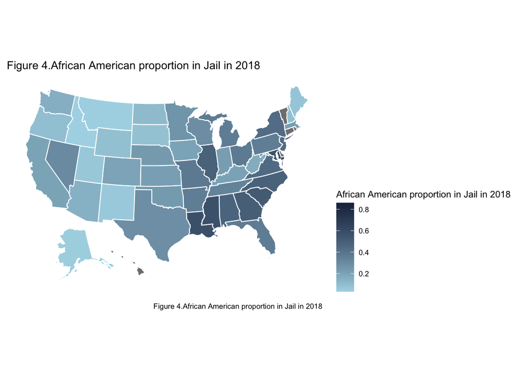

```r
plot_black_prop_year(2018)
```

To find the inequality trend in incarceration geographically, I created maps with the proportion of African Americans in Prison in 2018 and 1998. And from the map in 1998, there is a clear pattern that the southern part of America has a higher proportion than the northern part. And in 2018, the pattern still exists, but it’s weaker than in 1998. And my question for this part is how can we improve so that there will be no more inequity in incarceration?

*All the very best with your work!*